# Equidistant Ray Segmentation Method - under the hood

- Variant of the method EBSI Proposed by Du et al. (2015). “Stress wave tomography,” BioResources 10(3), 3948-3962.
- The segment lengths are comparable. Unlike Du, we do not use bisection of segments, but split to the legth close to the half of the shortest ray.
- Data in this sample are from Analysis of wave velocity patterns in black cherry trees and its effect on internal decay detection, https://www.sciencedirect.com/science/article/pii/S0168169914000684

**Citation from the paper**

> Table 3 shows the measured velocity data for sample 1-50. Fig. 9 illustrates the theoretical velocity model of the black cherry and the measured velocity data under source point 1, and Fig. 10 shows the tomogram of sample 1-50.

> It can be seen from Table 3 that, from source point 1, the wave velocities were 999 m/s (1-2), 1150 m/s (1-3), 1199 m/s (1-4), 1184 m/s (1-5), 1044 m/s (1-6), 764 m/s (1-7), 826 m/s (1-8), 1048 m/s (1-9), 1110 m/s (1-10), 1064 m/s (1-11), and 996 m/s (1-12). From Fig. 9, it can be seen that the line velocities of 1-5, 1-6, 1-7, 1-8, and 1-9 deviated from the theoretical values dramatically. The largest deviation was the line velocity for 1-7, which represents the radial direction.

> Consequently, we can speculate that internal decay exists in the central area of the cross section, and the decay area is surrounded by the lines 1-5 and 1-9, which matches with the tomogram of sample 1-50 reasonably well as shown in Fig. 10.

Here we select few rays for the processing. We can see segmentation (strips across the ellipses). The grid is extremely fine in order to have sharp boundaries of ellipses.

```python
import sys
sys.path.append('../src')
import tomotree as tomo
import numpy as np
import time

start_time = time.time()

# change colormap (add blue)
# from matplotlib.colors import LinearSegmentedColormap
# tomo.colors = ['blue','red', 'yellow', 'green']
# tomo.cmap = LinearSegmentedColormap.from_list('custom_colormap', tomo.colors)

#Table 3. Acoustic velocity data of sample 1-50 (unit: m/s).
#Test point,1,2,3,4,5,6,7,8,9,10,11,12
data_velocity = np.array([
1,np.nan,917,1150,1228,1217,1024,825,823,1040,1106,1069,940,
2,999,np.nan,965,1170,1228,1090,947,730,905,1055,1083,1113,
3,1150,881,np.nan,1025,1190,1111,1035,654,599,651,915,1067,
4,1199,1053,923,np.nan,997,1086,1127,1067,729,616,609,1014,
5,1184,1100,1096,972,np.nan,933,1143,1151,867,766,573,801,
6,1044,1003,1103,1145,1019,np.nan,960,1107,1047,999,679,657,
7,764,521,972,1119,1143,953,np.nan,936,1024,1046,849,677,
8,826,661,606,1097,1189,1143,955,np.nan,936,1125,1028,860,
9,1048,849,624,712,1008,1105,1080,1040,np.nan,1033,1063,999,
10,1110,949,539,613,720,1026,1086,1185,1018,np.nan,969,994,
11,1064,991,901,646,574,635,858,1057,1055,877,np.nan,798,
12,996,1083,1094,1100,1012,798,689,973,1048,977,861,np.nan]).reshape(12,-1)
data_velocity = data_velocity[:,1:]
t = tomo.Tomo (speeds=data_velocity, nx=201, ny=201, symmetric=True)
```

Select only few rays in order to see the segmentation of rays and ellipses.

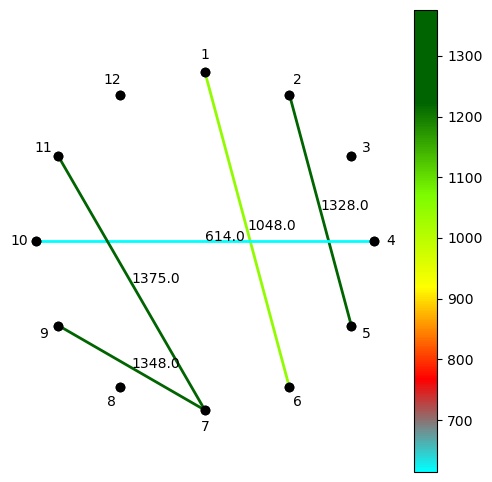

```python
def print_speeds(ax,t):
    for r in t.rays:
        for s in r.segments:
            ax.text(*(0.5*(s.start_coordinates+s.end_coordinates)),np.round(s.speed))

def findray(t,start, end):
    return [i for i in t.rays if i.start.number==start and i.end.number==end][0]

t.rays = [findray(t, *points) for points in [[1,6],[2,5],[4,10],[7,9],[7,11]]]
t.rays[-1].speed = 1300 # Fix the speed on the last ray
for s in t.rays[-1].segments:
    s.speed = 1300
t.fix_velocity_EBSI()  # Increase velocities in nonradial directions.
ax = t.plot(grid=False) # Plot the rays
print_speeds(ax, t) # Add speeds to the plot
```

Do the ERMS method and print information about the rays.

```python
t.do_ERSM_method(#fix_velocity_EBSI_function=lambda x,y:x,
                      n=2,
                      e_segmentation=0.99,
                      e_interpolation=0.98,
                      )
for r in t.rays:
    print(r)
```

```
Ray from node 1 to node 6. Speed 1048.0, 4 segments.
Ray from node 2 to node 5. Speed 1328.0, 3 segments.
Ray from node 4 to node 10. Speed 614.0, 5 segments.
Ray from node 7 to node 9. Speed 1348.0, 3 segments.
Ray from node 7 to node 11. Speed 1375.0, 4 segments.
```

Plot the rays.

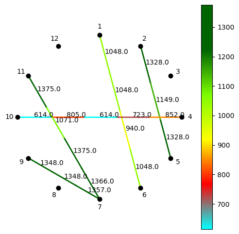

```python
_ = [j.speed for i in t.rays for j in i.segments]
bounds = {'speed_min': np.nanmin(_), 'speed_max': np.nanmax(_) }
ax = t.plot(grid=False, **bounds)
print_speeds(ax, t)
```

Plot the grid. Ellipses and their segments are clearly visible.

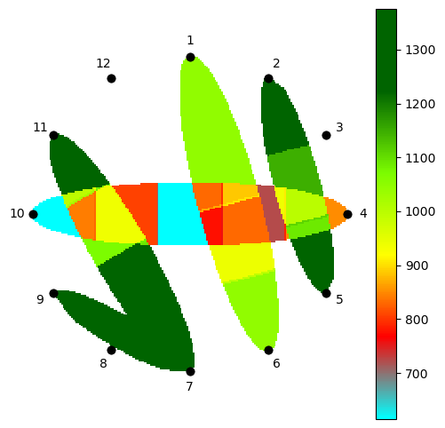

```python
_ = [i.velocity for i in t.grid.cells.values.reshape(-1) if i is not np.nan]
bounds = {'speed_min': np.nanmin(_), 'speed_max': np.nanmax(_) }
t.plot(rays=False, **bounds)
```